# Real-world data coding for neuroscientists (ReCoN)

### Solution to pandas analysis

```python
# import dataframe from csv file
data=pd.read_csv("parkinsons_disease_data.csv", index_col=0)
data
```

|  | PatientID | Age | Gender | Ethnicity | EducationLevel | BMI | Smoking | AlcoholConsumption | PhysicalActivity | DietQuality | ... | FunctionalAssessment | Tremor | Rigidity | Bradykinesia | PosturalInstability | SpeechProblems | SleepDisorders | Constipation | Diagnosis | DoctorInCharge |
| --- | --- | --- | --- | --- | --- | --- | --- | --- | --- | --- | --- | --- | --- | --- | --- | --- | --- | --- | --- | --- | --- |
| 0 | 3058 | 85 | Male | Other | 1 | 19.619878 | 0 | 5.108241 | 1.380660 | 3.893969 | ... | 1.572427 | 1 | 0 | 0 | 0 | 0 | 0 | 0 | CTRL | DrXXXConfid |
| 1 | 3059 | 75 | Male | Caucasian | 2 | 16.247339 | 1 | 6.027648 | 8.409804 | 8.513428 | ... | 4.787551 | 0 | 1 | 0 | 1 | 0 | 1 | 0 | PD | DrXXXConfid |
| 2 | 3060 | 70 | Female | Caucasian | 0 | 15.368239 | 0 | 2.242135 | 0.213275 | 6.498805 | ... | 2.130686 | 1 | 0 | 0 | 0 | 1 | 0 | 1 | PD | DrXXXConfid |
| 3 | 3061 | 52 | Male | Caucasian | 0 | 15.454557 | 0 | 5.997788 | 1.375045 | 6.715033 | ... | 3.391288 | 1 | 1 | 1 | 0 | 0 | 0 | 1 | PD | DrXXXConfid |
| 4 | 3062 | 87 | Male | Caucasian | 1 | 18.616042 | 0 | 9.775243 | 1.188607 | 4.657572 | ... | 3.200969 | 0 | 0 | 0 | 1 | 0 | 1 | 0 | CTRL | DrXXXConfid |
| ... | ... | ... | ... | ... | ... | ... | ... | ... | ... | ... | ... | ... | ... | ... | ... | ... | ... | ... | ... | ... | ... |
| 2100 | 5158 | 87 | Female | Caucasian | 2 | 38.483841 | 0 | 12.674393 | 5.325900 | 5.947278 | ... | 8.076254 | 1 | 0 | 0 | 0 | 1 | 1 | 0 | CTRL | DrXXXConfid |
| 2101 | 5159 | 67 | Male | Caucasian | 1 | 33.694396 | 1 | 0.977018 | 0.108599 | 4.825187 | ... | 1.665751 | 0 | 0 | 0 | 1 | 0 | 1 | 1 | PD | DrXXXConfid |
| 2102 | 5160 | 65 | Male | Caucasian | 2 | 22.829631 | 0 | 6.152286 | 5.775103 | 0.334244 | ... | 4.785614 | 0 | 0 | 0 | 0 | 1 | 1 | 0 | PD | DrXXXConfid |
| 2103 | 5161 | 61 | Female | Caucasian | 0 | 16.871030 | 1 | 0.292094 | 2.280475 | 9.598513 | ... | 8.378979 | 1 | 0 | 1 | 0 | 0 | 1 | 1 | PD | DrXXXConfid |
| 2104 | 5162 | 56 | Male | Caucasian | 2 | 16.569934 | 0 | 1.985084 | 1.400441 | 9.883835 | ... | 5.015131 | 0 | 0 | 0 | 0 | 1 | 0 | 1 | CTRL | DrXXXConfid |

2105 rows × 35 columns

```python
# How many rows and columns are in the dataframe?
data.shape
```

```
(2105, 35)
```

```python
# Are there any missing values? Generate summary statistics

# Look at numeric columns
display(data.describe()) # use display if you want to print something after

# Look at categorical columns
for col in data.select_dtypes(object).columns:
    print(col)
    print(len(data[col]))
```

|  | PatientID | Age | EducationLevel | BMI | Smoking | AlcoholConsumption | PhysicalActivity | DietQuality | SleepQuality | FamilyHistoryParkinsons | ... | UPDRS | MoCA | FunctionalAssessment | Tremor | Rigidity | Bradykinesia | PosturalInstability | SpeechProblems | SleepDisorders | Constipation |
| --- | --- | --- | --- | --- | --- | --- | --- | --- | --- | --- | --- | --- | --- | --- | --- | --- | --- | --- | --- | --- | --- |
| count | 2105.000000 | 2105.000000 | 2105.000000 | 2105.000000 | 2105.000000 | 2105.000000 | 2105.000000 | 2105.000000 | 2105.000000 | 2105.000000 | ... | 2105.000000 | 2105.000000 | 2105.000000 | 2105.000000 | 2105.000000 | 2105.000000 | 2105.000000 | 2105.000000 | 2105.000000 | 2105.000000 |
| mean | 4110.000000 | 69.601900 | 1.337292 | 27.209493 | 0.296437 | 10.040413 | 5.016674 | 4.912901 | 6.996639 | 0.145843 | ... | 101.415318 | 15.094314 | 4.989694 | 0.431829 | 0.252732 | 0.207601 | 0.138717 | 0.295012 | 0.245131 | 0.296912 |
| std | 607.805479 | 11.594511 | 0.895840 | 7.208099 | 0.456795 | 5.687014 | 2.890919 | 2.872115 | 1.753065 | 0.353033 | ... | 56.591448 | 8.643014 | 2.933877 | 0.495449 | 0.434682 | 0.405686 | 0.345733 | 0.456156 | 0.430267 | 0.457006 |
| min | 3058.000000 | 50.000000 | 0.000000 | 15.008333 | 0.000000 | 0.002228 | 0.004157 | 0.000011 | 4.000497 | 0.000000 | ... | 0.028441 | 0.021191 | 0.001505 | 0.000000 | 0.000000 | 0.000000 | 0.000000 | 0.000000 | 0.000000 | 0.000000 |
| 25% | 3584.000000 | 60.000000 | 1.000000 | 20.782176 | 0.000000 | 5.150278 | 2.455703 | 2.478503 | 5.488864 | 0.000000 | ... | 53.048148 | 7.517160 | 2.415890 | 0.000000 | 0.000000 | 0.000000 | 0.000000 | 0.000000 | 0.000000 | 0.000000 |
| 50% | 4110.000000 | 70.000000 | 1.000000 | 27.184571 | 0.000000 | 10.070337 | 5.031550 | 4.825187 | 6.929819 | 0.000000 | ... | 102.561023 | 14.963574 | 4.983227 | 0.000000 | 0.000000 | 0.000000 | 0.000000 | 0.000000 | 0.000000 | 0.000000 |
| 75% | 4636.000000 | 80.000000 | 2.000000 | 33.462452 | 1.000000 | 14.829565 | 7.512795 | 7.381487 | 8.558719 | 0.000000 | ... | 149.831682 | 22.608362 | 7.484220 | 1.000000 | 1.000000 | 0.000000 | 0.000000 | 1.000000 | 0.000000 | 1.000000 |
| max | 5162.000000 | 89.000000 | 3.000000 | 39.999887 | 1.000000 | 19.988866 | 9.995255 | 9.995864 | 9.999821 | 1.000000 | ... | 198.953604 | 29.970107 | 9.992697 | 1.000000 | 1.000000 | 1.000000 | 1.000000 | 1.000000 | 1.000000 | 1.000000 |

8 rows × 31 columns

```
Gender
2105
Ethnicity
2105
Diagnosis
2105
DoctorInCharge
2105
```

```python
# Select only rows with BMI between 19 and 25 and older than 60
# Use describe to verify

data=data.loc[(data.BMI>19) & (data.BMI<25) & (data.Age>60),:]
data.describe()
```

|  | PatientID | Age | EducationLevel | BMI | Smoking | AlcoholConsumption | PhysicalActivity | DietQuality | SleepQuality | FamilyHistoryParkinsons | ... | UPDRS | MoCA | FunctionalAssessment | Tremor | Rigidity | Bradykinesia | PosturalInstability | SpeechProblems | SleepDisorders | Constipation |
| --- | --- | --- | --- | --- | --- | --- | --- | --- | --- | --- | --- | --- | --- | --- | --- | --- | --- | --- | --- | --- | --- |
| count | 380.000000 | 380.000000 | 380.000000 | 380.000000 | 380.000000 | 380.000000 | 380.000000 | 380.000000 | 380.000000 | 380.000000 | ... | 380.000000 | 380.000000 | 380.000000 | 380.000000 | 380.000000 | 380.000000 | 380.000000 | 380.000000 | 380.000000 | 380.000000 |
| mean | 4129.734211 | 75.400000 | 1.368421 | 21.837120 | 0.307895 | 10.387287 | 5.027052 | 4.868685 | 7.003534 | 0.121053 | ... | 101.289237 | 15.312247 | 5.107942 | 0.442105 | 0.255263 | 0.223684 | 0.144737 | 0.318421 | 0.213158 | 0.276316 |
| std | 595.510194 | 8.171512 | 0.902095 | 1.737564 | 0.462231 | 5.789799 | 2.968512 | 2.869094 | 1.767887 | 0.326618 | ... | 59.063558 | 8.982069 | 2.859888 | 0.497292 | 0.436584 | 0.417262 | 0.352299 | 0.466478 | 0.410078 | 0.447764 |
| min | 3058.000000 | 61.000000 | 0.000000 | 19.022597 | 0.000000 | 0.003563 | 0.004157 | 0.000011 | 4.031393 | 0.000000 | ... | 1.272894 | 0.051162 | 0.074191 | 0.000000 | 0.000000 | 0.000000 | 0.000000 | 0.000000 | 0.000000 | 0.000000 |
| 25% | 3624.750000 | 69.000000 | 1.000000 | 20.232542 | 0.000000 | 5.265540 | 2.413981 | 2.406344 | 5.426956 | 0.000000 | ... | 49.837565 | 7.326370 | 2.535491 | 0.000000 | 0.000000 | 0.000000 | 0.000000 | 0.000000 | 0.000000 | 0.000000 |
| 50% | 4139.500000 | 75.000000 | 1.000000 | 21.783095 | 0.000000 | 10.535993 | 5.060863 | 4.837884 | 6.920406 | 0.000000 | ... | 104.038055 | 15.167978 | 5.221402 | 0.000000 | 0.000000 | 0.000000 | 0.000000 | 0.000000 | 0.000000 | 0.000000 |
| 75% | 4646.500000 | 82.250000 | 2.000000 | 23.308335 | 1.000000 | 15.750284 | 7.633864 | 7.390584 | 8.548951 | 0.000000 | ... | 154.153679 | 23.453441 | 7.565647 | 1.000000 | 1.000000 | 0.000000 | 0.000000 | 1.000000 | 0.000000 | 1.000000 |
| max | 5160.000000 | 89.000000 | 3.000000 | 24.980515 | 1.000000 | 19.979467 | 9.995255 | 9.995864 | 9.963080 | 1.000000 | ... | 198.894800 | 29.721958 | 9.990216 | 1.000000 | 1.000000 | 1.000000 | 1.000000 | 1.000000 | 1.000000 | 1.000000 |

8 rows × 31 columns

```python
# Drop column DoctorInCharge as it is not informative
data=data.drop(["DoctorInCharge"], axis=1)
```

```python
# How many different ethinicities are in the dataset, what are those and how many participants they include?
print(data.Ethnicity.unique())
print(data.Ethnicity.nunique())

print(data.value_counts("Ethnicity"))
```

```
['Other' 'Asian' 'Caucasian' 'African_American']
4
Ethnicity
Caucasian           241
African_American     70
Asian                37
Other                32
Name: count, dtype: int64
```

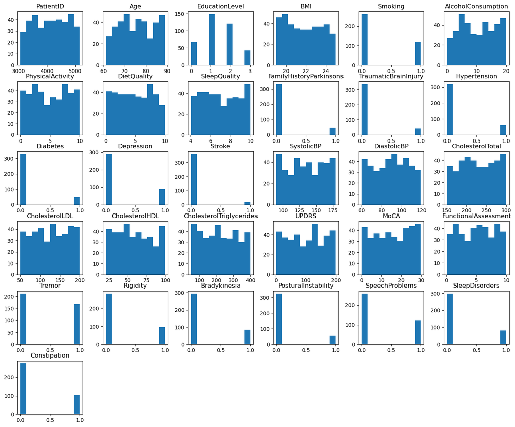

```python
# Plot distribution of numeric data on histograms, all columns
data.hist(grid=False, figsize=(17,14));
```

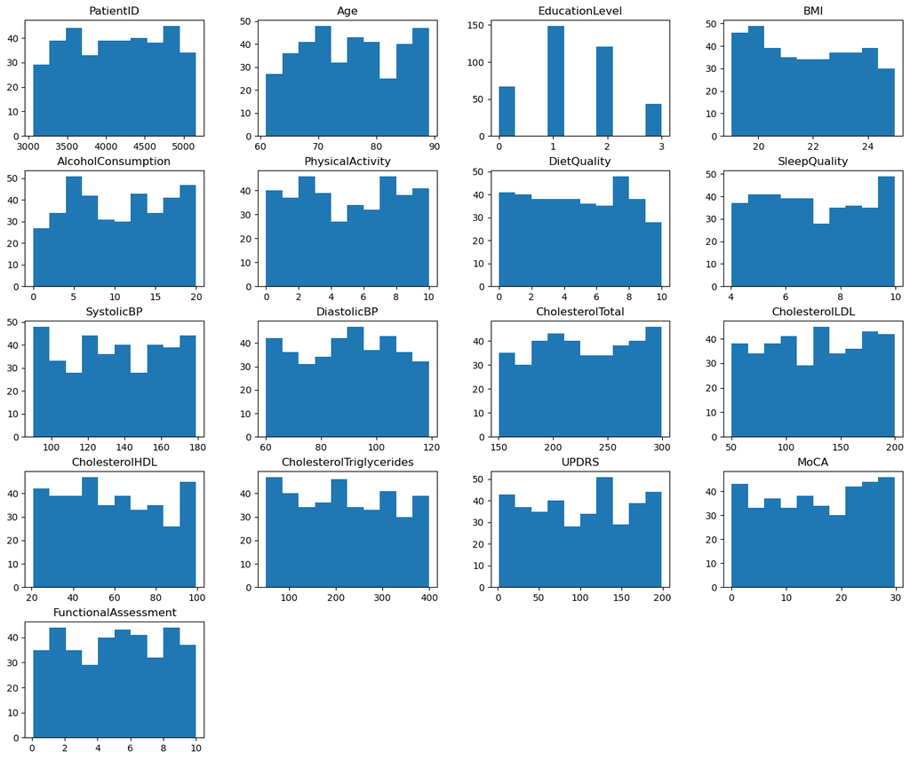

```python
# Plot histograms but this time include only those columns that have non-binary (0,1) content
non_binary_cols = [
    col for col in data.columns
    if not set(data[col].dropna().unique()).issubset({0, 1})
]

# Explanation of the logic above:
#
# For each column in the DataFrame:
#   1. data[col]            → selects the column
#   2. .dropna()            → removes NaN values
#   3. .unique()            → gets unique values
#   4. set(...)             → converts to a set for comparison
#   5. .issubset({0, 1})    → checks if all values are either 0 or 1
#   6. not ...              → we only want columns that are NOT binary
#
# The result is a list of column names that are NOT binary
# (i.e., continuous variables, text, scores, etc.)

# Filter the DataFrame
df_non_binary = data[non_binary_cols]

df_non_binary.hist(grid=False, figsize=(17,14));
```

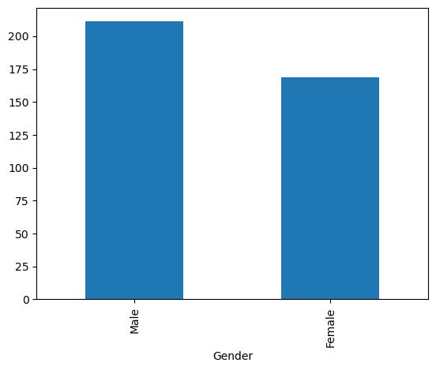

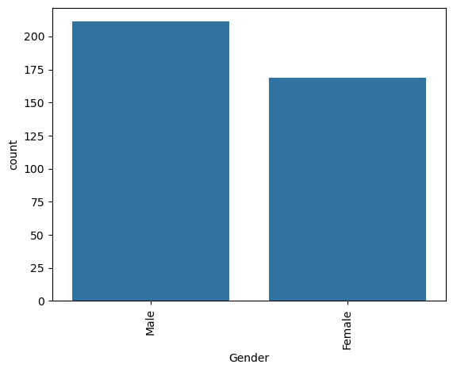

```python
# Plot countplot with number of records per gender category

#option one with pandas
import matplotlib.pyplot as plt
data.value_counts("Gender").plot(kind="bar")
plt.show()

#option two with seaborn
import seaborn as sns
sns.countplot(data, x="Gender")
plt.xticks(rotation=90)
plt.show()
```

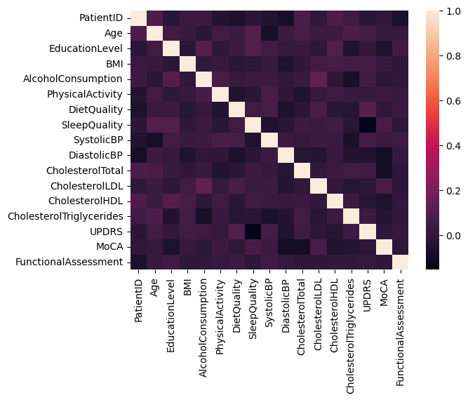

```python
# Plot correlation heatmap but use only columns with non binary data - prepared in the step before
sns.heatmap(df_non_binary.corr(numeric_only=True));
```

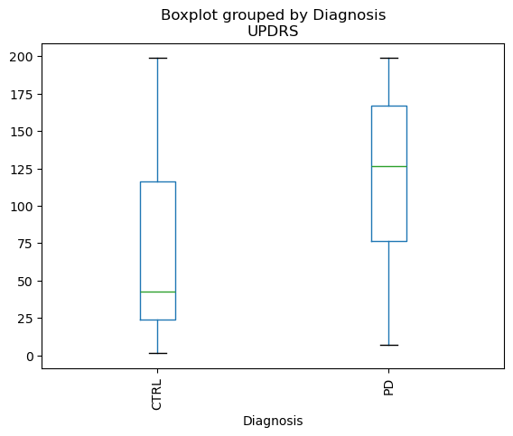

```python
# Plot boxplot with x axis representing Diagnosis and y axis representing UPDRS score
data.boxplot(column="UPDRS", by="Diagnosis", grid=False, rot=90);
```

### 9. Gentle introduction to numpy

NumPy is the fundamental package for scientific computing in Python. It is a Python library that provides a multidimensional array object, various derived objects (such as masked arrays and matrices), and an assortment of routines for fast operations on arrays, including mathematical, logical, shape manipulation, sorting, selecting, I/O, discrete Fourier transforms, basic linear algebra, basic statistical operations, random simulation and much more.

- NumPy arrays have a fixed size at creation, unlike Python lists (which can grow dynamically). Changing the size of an ndarray will create a new array and delete the original.
- The elements in a NumPy array are all required to be of the same data type, and thus will be the same size in memory.
- NumPy arrays facilitate advanced mathematical and other types of operations on large numbers of data.

| **Name** | **Type** | **Description** |
| --- | --- | --- |
| `ndarray.shape` | Attribute | Returns a tuple representing the dimensions of the array. |
| `ndarray.ndim` | Attribute | Returns the number of dimensions (axes) of the array. |
| `ndarray.size` | Attribute | Returns the total number of elements in the array. |
| `ndarray.dtype` | Attribute | Returns the data type of the array elements. |
| `ndarray.T` | Attribute | Returns the transposed version of the array. |
| `np.array()` | Method | Creates a NumPy array from a Python list or tuple. |
| `np.zeros()` | Method | Creates an array filled with zeros. |
| `np.ones()` | Method | Creates an array filled with ones. |
| `np.arange()` | Method | Creates an array with regularly spaced values within a range. |
| `np.reshape()` | Method | Changes the shape of an array without changing its data. |
| `np.sum()` | Method | Computes the sum of array elements. |
| `np.mean()` | Method | Computes the mean (average) of the array elements. |
| `np.std()` | Method | Computes the standard deviation. |
| `np.max()` | Method | Returns the maximum value in the array. |
| `np.min()` | Method | Returns the minimum value in the array. |

```python
import numpy as np
```

#### 9.1. Creating arrays

```python
# Create a 1D array
arr1 = np.array([1, 2, 3, 4])
print("1D array:", arr1)

# Create a 2D array
arr2 = np.array([[1, 2, 3], [4, 5, 6]])
print("2D array:\n", arr2)

# Create arrays with default values
zeros = np.zeros((2, 3))     # 2 rows, 3 columns of zeros
ones = np.ones((3, 2))       # 3 rows, 2 columns of ones


print("Zeros:\n", zeros)
print("Ones:\n", ones)

# Create a sequence of numbers
# Use arange function - analogous to range with start, step and interval

print("Ranges")
print(np.arange(10, 30, 5))
print(np.arange(4))
```

#### 9.2. Array operations

```python
a = np.array([1, 2, 3])
b = np.array([4, 5, 6])

# Element-wise operations
print("a + b:", a + b)
print("a * b:", a * b)
print("a squared:", a ** 2)
```

#### 9.3 Basic numpy functions and array attributes

```python
arr = np.array([[1, 2, 3], [4, 5, 6]])

print("Shape:", arr.shape)
print("Data type:", arr.dtype)
print("Max:", np.max(arr))
print("Min:", np.min(arr))
print("Sum:", np.sum(arr))
print("Mean:", np.mean(arr))
print("Standard Deviation:", np.std(arr))
```

#### 9.4 More complex but very useful numpy functions

- `concatenate()` - function is used to join two or more arrays along an existing axis
- `convolve()` - performs a discrete, linear convolution of two 1-dimensional sequences

```python
# 1D Arrays
a = np.array([1, 2, 3])
b = np.array([4, 5, 6])

# Concatenate along axis 0
result_1d = np.concatenate((a, b))
print("1D Concatenation:", result_1d)

# 2D Arrays
c = np.array([[1, 2], [3, 4]])
d = np.array([[5, 6]])

# Concatenate along axis 0 (rows)
result_2d_axis0 = np.concatenate((c, d), axis=0)
print("2D Concatenation along axis 0:\n", result_2d_axis0)

# Concatenate along axis 1 (columns)
e = np.array([[7], [8]])
result_2d_axis1 = np.concatenate((c, e), axis=1)
print("2D Concatenation along axis 1:\n", result_2d_axis1)
```

```python
# Convolution "slides" the kernel over the signal and multiplies-and-sums overlapping values.

# Signal and kernel
signal = np.array([1, 2, 3])
kernel = np.array([0, 1, 0.5])

# Full convolution
full = np.convolve(signal, kernel, mode='full')
print("Full:", full)

# Same size as original
same = np.convolve(signal, kernel, mode='same')
print("Same:", same)

# Valid part only (no padding)
valid = np.convolve(signal, kernel, mode='valid')
print("Valid:", valid)
```

### 10. Introduction to functions

In this lesson, you will learn how to design, implement, and organise your code with functions. As you will realise further on, functions are just a piece of code that will let you perform a specific task multiple times without duplicating any code.

### 10.1 Definitions

Every function has 2 parts: a header and a body. The header specifies the name of the function and its argument(s). The body specifies the work that the function does.

For example,

```python
def multiply_by_five(input_variable):
    output_variable = input_variable * 5
    return output_variable
```

In this case, the header will be the part composed by:

**def multiply_by_five(input_variable):**

and the body is the rest of the function:

**output_variable = input_variable * 5**

**return output_variable**

→ **def**: This is the key word that tells Pyhton we are about to define a function.

→ **multiply_by_five**: This is the name you choose for your function. It can be whatever you like.

→ **(input_variable):**: This is called the argument. It is the name of the variable the function will use. You can also have a function with no argument, or with multiple arguments. It is always enclosed in parantheses that appear immediately after the name of the function. For every function, the parentheses enclosing the function argument(s) must be followed by a colon : .

→ **return**: This is the key word that tells Python we are about to exit a function.

→ **output_variable** is the value that is returned when the function is exited. You can add as many values as you like the function to return.

### 10.2 How to run (or "call") a function

In the code below, we run the function with 10 as the input value. It is important to note that the new variables created inside the function will not be callable outside, and vice versa: the elements that are not in the argument will not be able to be used inside the body of the function.

Let's see an example of these rules.

```python
# first, we can define our original variable:

my_number = 10
print(my_number)
```

```python
# now, we can call the function with that input value, and obtain the output:

new_number = multiply_by_five(my_number)
print(new_number)
```

What we have learned so far:

1. We have to run the function **BEFORE** we call it. Sometimes, developers place all the functions at the top of the document and then they run the code.
2. The name of the function should only use lowercase letters, with words separated by underscores and **NOT** spaces. As for the variables, the functions should not start with a number; e.g. 5_multiply() would be wrong.

```python
def 2_print_hello():
    print("Hello World!")

2_print_hello()
```

Naming, designing and calling fuctions will feel natural over time. It is normal for it to feel uncomfortable at first. To fix this, let's go over some easy examples.

### 10.3 Examples

##### 10.3.1 Functions with no arguments.

```python
def my_function():
  print("Hello world!")

my_function()
```

```
Hello world!
```

```python
# Try it yourself! Write a function that prints "Hello World!" 5 times.

def my_function():
    for i in range(5):
        print("Hello world!")

my_function()
```

```
Hello world!
Hello world!
Hello world!
Hello world!
Hello world!
```

```python
# Those functions are called "void" functions, as they do not return any values.
# you can also return a value from a function.

# The elements inside the function that are not returned will not be callable outside the function. e.g:
def my_function():
    string = "Hello World!"
    number = 5    # randomly create a variable to test this
    return string

string = my_function()
print(string)
print(number)
# as you can see, the string returned is accessible outside the function, but the number is not
```

```
Hello World!
```

```
---------------------------------------------------------------------------
NameError                                 Traceback (most recent call last)
Cell In[3], line 12
     10 string = my_function()
     11 print(string)
---> 12 print(number)
     13 # as you can see, the string returned is accessible outside the function, but the number is not

NameError: name 'number' is not defined
```

```python
# Functions cannot be empty, but if you have a function definition with no content, you can add the pass statement to avoid errors:
def my_function():
```

```
  Cell In[4], line 2
    def my_function():
                      ^
_IncompleteInputError: incomplete input
```

```python
def my_function():
    pass

# this does not return anything, but is not an error
my_function()
```

```python
print(my_function())
```

```
None
```

##### 10.3.2 Functions with strings

```python
def add_surname(name):
    return name + " Smith" # we don't have to create a variable. We can just return the result.

print(add_surname("John"))
print(add_surname("Michael"))
print(add_surname("Paul"))
```

```
John Smith
Michael Smith
Paul Smith
```

```python
# we can also see that if we add the wrong number of arguments, we will get an error:
print(add_surname("John", "Michael"))
```

```
---------------------------------------------------------------------------
TypeError                                 Traceback (most recent call last)
Cell In[8], line 2
      1 # we can also see that if we add the wrong number of arguments, we will get an error:
----> 2 print(add_surname("John", "Michael"))

TypeError: add_surname() takes 1 positional argument but 2 were given
```

It is important that you understand how to read and understand these errors and not rely on AI to tell you what they mean!

```python
# Try it yourself! Do a function that will replace the base T for U in a DNA sequence.

def replace_t_u(sequence):
    print(sequence.replace("T", "U"))

replace_t_u("ATGTTC")
```

```
AUGUUC
```

```python
# Try it yourself! Write a function that cleans a sentence from different punctuation marks.
    # HINT: there is a python method that can replace specific charaters with another specific set of characters.
    # https://docs.python.org/3/library/stdtypes.html#str.replace - look for str.replace() to read the documentation.

def clean_sentence(string):
    clean = string.replace(",", " ").replace("_", " ").replace(":", " ").replace("|", " ").replace("&", " ")
    return clean

clean_sentence(string = "Hello,world!&My_name|is:John")
```

```
'Hello world! My name is John'
```

```python
# You can also pass a list as an argument the same way you would pass a string.
def list_items(items):
    print(items)

list_items(["pineapples", "banana", "oranges"])
```

```
['pineapples', 'banana', 'oranges']
```

##### 10.3.3 Arbitrary arguments. Choosing from a tuple.

```python
# If you are unsure about the number of arguments that will be passed into your function,
# you can add a * before the parameter name in the function definition.

# an example with a tuple as the input:
def find_youngest(*ages):
    print("The youngest person is ", ages[-1], " years old")

find_youngest(12, 10, 8, 6)
```

```
The youngest person is  6  years old
```

```python
# Try it yourself! Create a function that will find the average of heart rate measurements given an undefined list of measurements.

def avg_heart_rate(*heart_rates):
    return sum(heart_rates) / len(heart_rates)

average = avg_heart_rate(120, 70, 80, 68, 55, 90)
print(average)
```

```
80.5
```

```python
# Try it yourself! Create a function that will find the total count of a specific base in any number of given DNA sequences.

def count_bases(*sequences, matched_base):
    count = 0
    for sequence in sequences:
        for base in sequence:
            if base == matched_base:
                count += 1
    return count

total_match = count_bases("ATCGCG", "GGGTTTGCACT", "ACCGCTAGG", matched_base='C')
print(total_match)
```

```
7
```

##### 10.3.4 Keyword arguments

```python
# If you have a function with many parameters, you can use kwyword arguments to pass the correct values to the function.
def sum_and_multiply(sum1, sum2, sum3, multiply2, multiply3):
    sum_result = sum1 + sum2 + sum3

    multiply_result = sum_result * multiply2 * multiply3

    return multiply_result

result = sum_and_multiply(sum1=1, sum2=2, sum3=3, multiply2=4, multiply3=5)
print(result)
```

```
120
```

```python
# an interesting thing to note is that the order of the arguments does not matter as long as they are named.

# Try it yourself!

result2 = sum_and_multiply(multiply3=5, sum2=2, sum1=1, sum3=3, multiply2=4)
print(result2)
```

```
120
```

```python
# Now, try removing the names of some of the arguments, and see what happens.
result3 = sum_and_multiply(1, sum2=2, 3, multiply2=4, multiply3=5)
print(result3)

# If you get an error (positional argument follows keyword argument), that's okay.
# This means that the function is expecting the arguments to be in a specific order.
# If you remove the names, the function will not know which value belongs to which parameter. If you want to remove some names, and not others, you can only remove the names of the first parameters.
# For example, this will work:
result4 = sum_and_multiply(1, 2, 3, multiply2=4, multiply3=5)
print(result4)
```

```
  Cell In[17], line 2
    result3 = sum_and_multiply(1, sum2=2, 3, multiply2=4, multiply3=5)
                                                                     ^
SyntaxError: positional argument follows keyword argument
```

```python
# but this will not:
result5 = sum_and_multiply(1, 2, 3, multiply2=4, 5)
print(result5)
```

```
  Cell In[18], line 2
    result5 = sum_and_multiply(1, 2, 3, multiply2=4, 5)
                                                      ^
SyntaxError: positional argument follows keyword argument
```

##### 10.3.5 Arbitrary keyword arguments (kwargs)

```python
# If you do not know how many keyword arguments that will be passed into your function, add two asterisk: ** before the parameter name in the function definition.
# This way the function will receive a *dictionary* of arguments, and can access the items accordingly:


# .......... REVIEW THIS EXAMPLE INTO DICTIONARY ......


def sum_squares(**numbers):
    sum_squares = numbers["num1"]**2 + numbers["num2"]**2
    return sum_squares
result = sum_squares(num1=2, num2=4, num3=6)
print(result)
```

```
20
```

```python
# Try it yourself! Create a function that will find add a random amount of metadata to a given participant and return the updated participant info in dictionary format.

def add_metadata(subject_id, **metadata):
    return {"subject_id": subject_id, **metadata}

participant_info = add_metadata("S-10", gender="female", age=25, height=170, weight=60)
print(participant_info)
```

```
{'subject_id': 'S-10', 'gender': 'female', 'age': 25, 'height': 170, 'weight': 60}
```

```python
# Try it yourself! Create a function that will accept any set of channels (e.g. gNA, gK, gLeak, etc) and return the total and the normalized fractions per channel

# HINT: to access the arguments in the functions, you can use the .items() method. https://docs.python.org/3/library/stdtypes.html#dict.items
# for example, if you have a dictionary and want to access the keys and the values:
my_dict = {
    "key1": "value1",
    "key2": "value2",
    "key3": "value3",
    "key4": "value4"
}

for key, value in my_dict.items():
    print(key, value)

def channel_fractions(**channels):
     total = sum(channels.values())
     fractions = {}
     for channel, value in channels.items():
         fractions[channel] = value / total
     return total, fractions

total, fractions = channel_fractions(gNa=120, gK=36, gLeak=0.3)
print(f"Total conductance: {total}")
print(f"Fractions: {fractions}")
```

```
key1 value1
key2 value2
key3 value3
key4 value4
Total conductance: 156.3
Fractions: {'gNa': 0.7677543186180422, 'gK': 0.23032629558541265, 'gLeak': 0.0019193857965451053}
```

##### 10.3.6 Default parameter value

```python
# You will find situations where you will want to set a default parameter value, that can be overridden with a new value upon request.
def sum_squares(num1=5, num2=10):
    sum_squares = num1**2 + num2**2
    return sum_squares

result = sum_squares() # the default values that are used are 5, and 10, respectively.
print(f'The result with the default values is {result}')

result = sum_squares(num2 = 20) # we can change only one of the values
print(f'The result with num2=20 is {result}')

result = sum_squares(4, 3) # or override both values
print(f'The result with num1=4, and num2=3 is {result}')
```

```
The result with the default values is 125
The result with num2=20 is 425
The result with num1=4, and num2=3 is 25
```

```python
# You can set the default value to any data type, such as dictionaries, lists, tuples, boolean values, etc.
# Let's practice with a boolean value. Try it yourself! Create a function that ignores a specific base or bases of a DNA sequence. If multple bases are added, ignore any matching bases. No need to match the order.

def ignore_bases(sequence, *bases, ignore=True):
    if ignore:
        for base in bases:
            sequence = sequence.replace(base, "")
    return sequence


original_sequence = "ATCGATCGATCG"
print(original_sequence)

new_sequence = ignore_bases(original_sequence, "A", "T", "C", ignore=True)
print(new_sequence)

# now, make sure it works with a single base
new_sequence2 = ignore_bases(original_sequence, "A", ignore=True)
print(new_sequence2)
```

```
ATCGATCGATCG
GGG
TCGTCGTCG
```

##### 10.3.7 Calculate the total number of occurances of the base (A, C, T, G) in a given DNA sequence

```python
def count_base(sequence, base):
    base_count = 0  # We have to initialise the variable that will count the numbers

    # To loop through the sequence, we have to loop from 0 until the end.
    # First, we have to find the length of the sequence.
    sequence_length = len(sequence)

    for idx in range(sequence_length):
        seq_base = sequence[idx] # this is the base for the current index.
        if seq_base == base: # if the current sequence matches the base, we add 1 to the base_counter
            base_count += 1

    return base_count

# We have now defined the function. Let's define the variables:
sequence1 = 'ACGTACGTACGT'
sequence2 = 'TTATCGACTTC'

base1 = 'C'

sequence1_count = count_base(sequence1, base1)
print(f"In the first squence, {sequence1}, the base {base1} appears {sequence1_count} times")

# we can also use the function without defining the variable if we don't want to store it in memory
sequence2_count = count_base(sequence2, "T")
print(f"In the second squence, {sequence2}, the base 'T' appears {sequence2_count} times")
```

```
In the first squence, ACGTACGTACGT, the base C appears 3 times
In the second squence, TTATCGACTTC, the base 'T' appears 5 times
```

It is good practice to document the function you are creating for future use, especially if you are working with multiple people on a project. You need to define what the arguments inputs are, what the function does, and what it returns. If working with multiple variables and data structures, additional documentation would include the shape, size or type of the array that it returns.

```python
# one way to document the function is the following:
def count_base(sequence, base):
    '''
    Calculate the total number of occurances of a base in a DNA sequence.

    Args:
        sequence: str, the DNA sequence to be analysed
        base: str, the base to count in the sequence

    Returns:
        base_count: int, the total number of occurances in the sequence

    '''
    base_count = 0
    sequence_length = len(sequence)

    # Loop through every base in the sequence
    for idx in range(sequence_length):
        seq_base = sequence[idx]

        # Match the current base to the desired base
        if seq_base == base:
            base_count += 1

    return base_count
```

```python
# As you can see, we used the function "range()" to loop thruogh the sequence. Let's practice with this.
x = range(3, 10)
print(x)
```

```
range(3, 10)
```

```python
# This creates a sequence of each of the numbers from 3 to 9:
for i in x:
    print(i)
```

```
3
4
5
6
7
8
9
```

```python
# if we want to access the elements of the sequence:
for idx, value in enumerate(x):
    print("index: ", idx, " value: ", value)
```

```
index:  0  value:  3
index:  1  value:  4
index:  2  value:  5
index:  3  value:  6
index:  4  value:  7
index:  5  value:  8
index:  6  value:  9
```

Remember that python indexing starts from 0.

```python
# We can also add a step to the range. For example, let's print all the even numbers between 0 and 10:
x = range(0, 10, 2)
for i in x:
    print(i)
```

```
0
2
4
6
8
```

```python
# we can also access the elements as a list by converting the range to a list:
print(list(x))
```

```
[0, 2, 4, 6, 8]
```

```python
# And only accessing the first 5 elements:
x = range(0, 20, 2)
y = x[:5]
print('Original list: ', list(x))
print('First 5 elements of the list: ', list(y))
```

```
Original list:  [0, 2, 4, 6, 8, 10, 12, 14, 16, 18]
First 5 elements of the list:  [0, 2, 4, 6, 8]
```

##### 10.3.8 Examples with increasing complexity comprising all these concepts

```python
# Convert a DNA sequence to RNA (by replacing T with U in the sequence)
def convert_to_rna(dna):
    rna = dna.replace("T", "U")
    return rna

rna = convert_to_rna("ATGTTCA")
print(f'The RNA sequence is {rna}')

# what if the string is not clean?
rna = convert_to_rna("atgTtca")
print(f'The RNA sequence is {rna}')

# it will only convert the EXTACT matches. Try creating a function that will convert all the bases to uppercase:

def convert_to_rna(dna):
    rna = dna.upper().replace("T", "U")
    return rna
rna = convert_to_rna("atgTtca")
print(f'The RNA sequence is {rna}')
```

```
The RNA sequence is AUGUUCA
The RNA sequence is atgUtca
The RNA sequence is AUGUUCA
```

```python
# Count the total number of codon occurances in a large DNA sequence. Adapt to count more than one codon.

# Add your code here

def count_codons(sequence, *codons):
    for codon in codons:
        codon_count = sequence.count(codon)
        print(f'The codon {codon} appears {codon_count} times in the sequence')

count_codons("ATGAAAATGCCCAATGGHS", "ATG", "GCC")
```

```
The codon ATG appears 3 times in the sequence
The codon GCC appears 1 times in the sequence
```

```python
# Access the centre point of a nested array (centroid).

def access_centroid(array):
    rows = len(array)
    cols = len(array[0])
    centroid = [rows//2, cols//2]
    centroid_value = array[centroid[0]][centroid[1]]
    return centroid, centroid_value

array = [[1, 2, 3, 4, 5],
         [4, 5, 6, 3, 7],
         [7, 8, 9, 7, 1]]

centroid, value = access_centroid(array)
print("The centroid location in the array is: ", centroid)
print("The value at the centroid is: ", value)
```

```
The centroid location in the array is:  [1, 2]
The value at the centroid is:  6
```

```python
# What if the nested array is missing some values?
array = [[1, 2, 3,     ],
         [4, 5, 6, 3, 7],
         [7, 8, 9, 7   ]]

centroid, value = access_centroid(array)
print("The centroid location in the array is: ", centroid)
print("The value at the centroid is: ", value)

# We can clean the data by imputing the missing values with various methods. You can try it with the mean of all the values in that row.
def clean_array(array, method="mean"):
    width = max(len(row) for row in array)
    total_mean = sum(sum(row) for row in array) / sum(len(row) for row in array)
    for row in array:
        if len(row) < width:
            number_missing_cols = width - len(row)
            for i in range(number_missing_cols, width-1):
                if method == "mean":
                    row.append(int(sum(row) / len(row)))
                elif method == "total_mean":
                    row.append(int(total_mean))
    return array

cleaned_array = clean_array(array, "total_mean")
print("The new cleaned array is: ", cleaned_array)

centroid, value = access_centroid(cleaned_array)
print("The centroid location in the cleaned array is: ", centroid)
print("The value at the centroid is: ", value)
```

```
The centroid location in the array is:  [1, 1]
The value at the centroid is:  5
The new cleaned array is:  [[1, 2, 3, 5, 5], [4, 5, 6, 3, 7], [7, 8, 9, 7, 5, 5, 5]]
The centroid location in the cleaned array is:  [1, 2]
The value at the centroid is:  6
```

```python
# Analyse the spike trains of an input neuron. Adapt for multple neurons. Return mean, median and standard deviation of each of the spike trains.
        # HINT: you can add nested functions inside another function to further modularise your code. In this example, we have added four nested functions to calculate the four different metrics.

# LEAVE SOME SPACES BLANK FOR THEM TO FILL IN

def analyze_spike_train(*trains, start, end):
    # Add smaller, locally-available functions to calculate each metric
    def calculate_mean(train):
        return sum(train) / len(train)

    def calculate_median(train):
        return sorted(train)[len(train)//2]

    def calculate_std(train):
        mean = calculate_mean(train) # calculate the mean of the train
        return (sum((x-mean)**2 for x in train) / len(train))**0.5

    def sampling_frequency(train, start, end):
        return len(train) / (end - start)


    data = {}
    for idx, train in enumerate(trains):
        data[f"Train {idx+1}"] = {}
        data[f"Train {idx+1}"]["mean"] = calculate_mean(train)
        data[f"Train {idx+1}"]["median"] = calculate_median(train)
        data[f"Train {idx+1}"]["std"] = calculate_std(train)
        data[f"Train {idx+1}"]["sampling_freq"] = sampling_frequency(train, start, end)

    return data



train1 = [0.05, 0.10, 0.30, 0.305, 1.2]
train2 = [0.02, 0.50, 0.70, 1.1, 1.4, 1.41]

data = analyze_spike_train(train1, train2, start=0.0, end=1.5)
print(data)
```

```
{'Train 1': {'mean': 0.39099999999999996, 'median': 0.3, 'std': 0.4174014853830781, 'sampling_freq': 3.3333333333333335}, 'Train 2': {'mean': 0.855, 'median': 1.1, 'std': 0.502054113949217, 'sampling_freq': 4.0}}
```